# Statistical Programming, Simulation and Modeling

Dr. Basim Alsaedi

2025-04-12

# Introduction

# What is Statistical Programming?

Statistical programming combines:

- Programming skills
- Statistical knowledge

To perform tasks like:

- Data cleaning and preparation
- Exploration and visualization
- Statistical modeling
- Simulation and hypothesis testing
- Reproducible analyses

# Why Learn Statistical Programming?

- **Data literacy**: Understand and communicate with data
- **Problem-solving**: Apply statistics to real-world problems
- **Career opportunities**: Skills for data science and analytics
- **Research capabilities**: Design and conduct statistical analyses

# Probability Distributions and Simulation

# Why Simulate Data?

Simulation helps us:

- Understand theoretical distribution properties
- Test hypotheses when analytical solutions are difficult
- Generate synthetic data for testing
- Model real-world processes

# Normal Distribution

The normal distribution has the familiar bell shape:

$$f(x) = \frac{1}{\sigma\sqrt{2\pi}}e^{-
\frac{(x - \mu)^{2}}{2\sigma^{2}}}$$

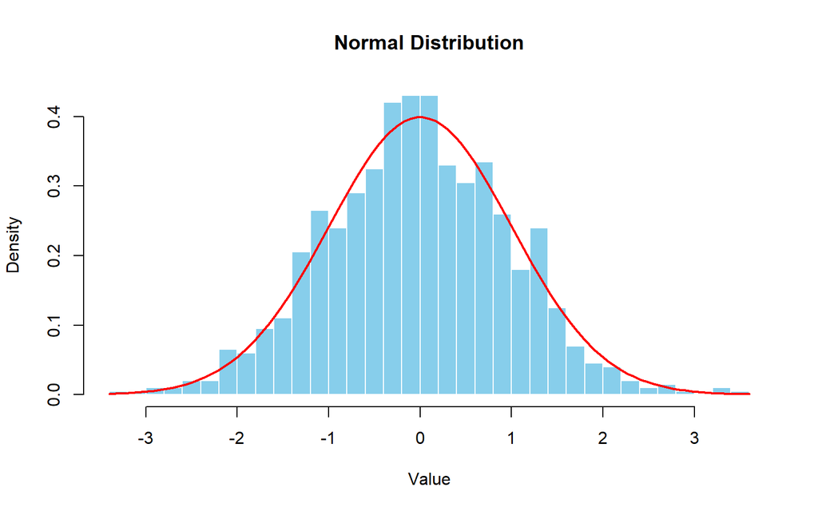

# Simulating Normal Data in R

```r
# Generate random values from a normal distribution
normal_data <- rnorm(1000, mean = 0, sd = 1)

# Plot a histogram
hist(normal_data, breaks = 30, col = "skyblue", border = "white",
     main = "Normal Distribution",
     xlab = "Value", prob = TRUE)

# Add theoretical density curve
curve(dnorm(x, mean = 0, sd = 1), add = TRUE, col = "red", lwd = 2)
```

# Normal Distribution: Real-world Example

**Human Heights**:

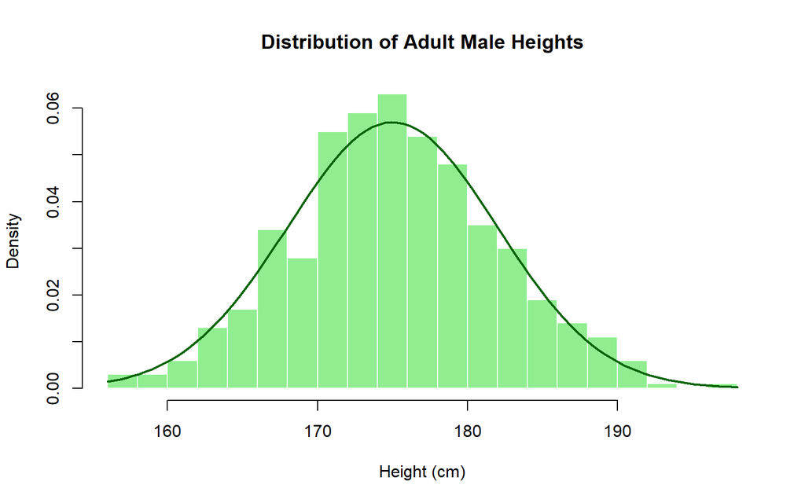

# Binomial Distribution

Models the number of successes in fixed trials:

$$P(X = k) = \binom{n}{k}p^{k}(1 - p)^{n -
k}$$

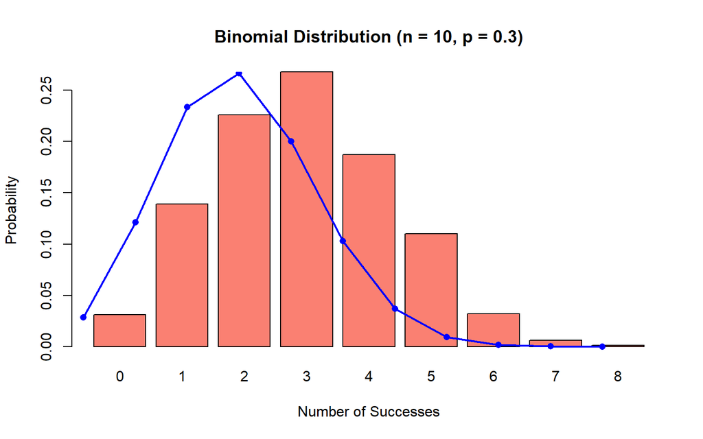

# Simulating Binomial Data in R

```r
# Generate binomial random values
binomial_data <- rbinom(1000, size = 10, prob = 0.3)

# Plot the distribution
barplot(table(binomial_data)/1000, col = "salmon",
        main = "Binomial Distribution (n = 10, p = 0.3)",
        xlab = "Number of Successes", ylab = "Probability")

# Add theoretical probabilities
points(0:10, dbinom(0:10, size = 10, prob = 0.3),
       pch = 16, col = "blue")
lines(0:10, dbinom(0:10, size = 10, prob = 0.3),
      col = "blue", lwd = 2)
```

# Binomial Distribution: Real-world Example

**Coin Flips**:

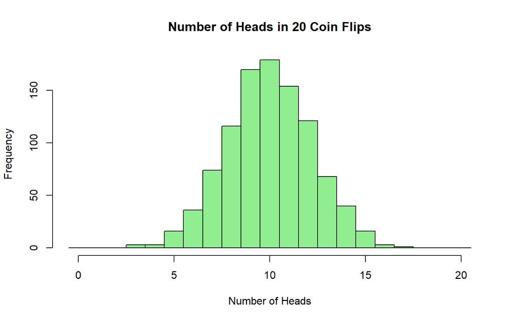

# Poisson Distribution

Models events in fixed time/space intervals:

$$P(X = k) = \frac{\lambda^{k}e^{-
\lambda}}{k!}$$

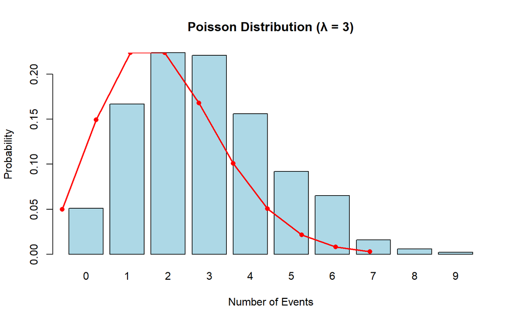

# Simulating Poisson Data in R

```r
# Generate Poisson random values
poisson_data <- rpois(1000, lambda = 3)

# Plot the distribution
barplot(table(poisson_data)/1000, col = "lightblue",
        main = "Poisson Distribution (λ = 3)",
        xlab = "Number of Events", ylab = "Probability")

# Add theoretical probabilities
points(0:max(poisson_data), dpois(0:max(poisson_data), lambda = 3),
       pch = 16, col = "red")
lines(0:max(poisson_data), dpois(0:max(poisson_data), lambda = 3),
      col = "red", lwd = 2)
```

# Poisson Distribution: Real-world Example

**Call Center Arrivals**:

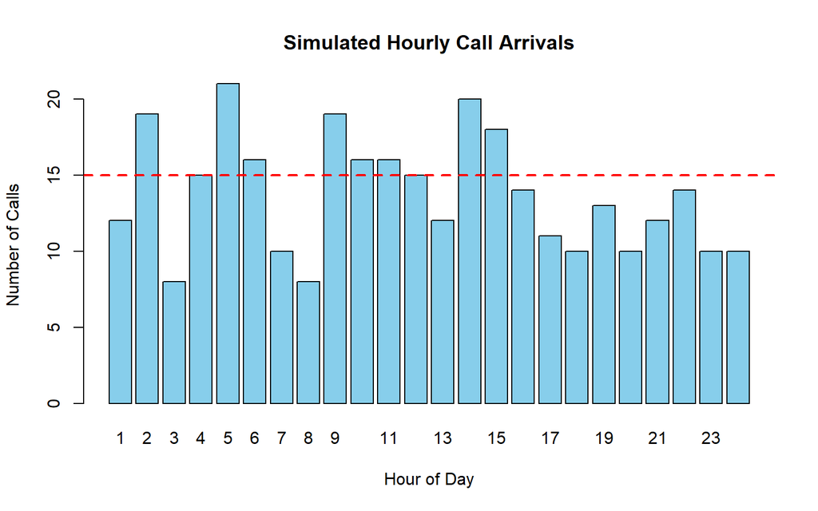

# Uniform Distribution

Equal probability across all values in a range:

$$f(x) = \frac{1}{b - a}, \quad a \leq x
\leq b$$

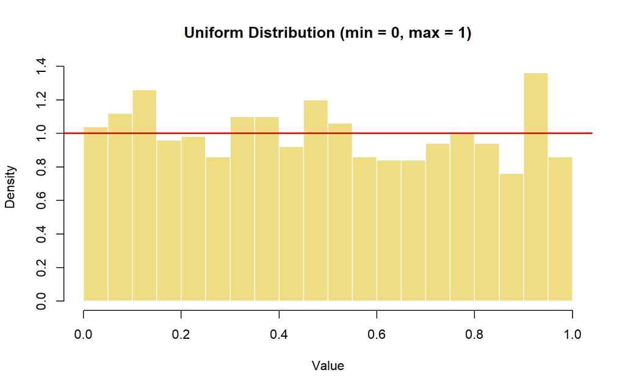

# Simulating Uniform Data in R

```r
# Generate uniform random values
uniform_data <- runif(1000, min = 0, max = 1)

# Plot a histogram
hist(uniform_data, breaks = 20, col = "lightgoldenrod", border = "white",
     main = "Uniform Distribution (min = 0, max = 1)",
     xlab = "Value", prob = TRUE)

# Add the theoretical density line
abline(h = 1, col = "red", lwd = 2)
```

# Exponential Distribution

Models time between events:

$$f(x) = \lambda e^{-\lambda x}, \quad x
\geq 0$$

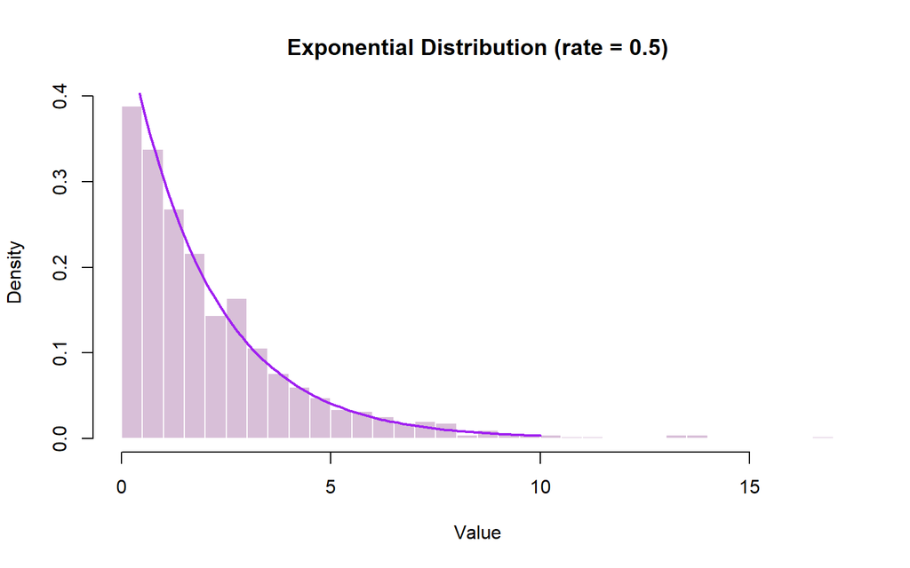

# Simulating Exponential Data in R

```r
# Generate exponential random values
exponential_data <- rexp(1000, rate = 0.5)

# Plot a histogram
hist(exponential_data, breaks = 30, col = "thistle", border = "white",
     main = "Exponential Distribution (rate = 0.5)",
     xlab = "Value", prob = TRUE)

# Add the theoretical density curve
curve(dexp(x, rate = 0.5), from = 0, to = 10, add = TRUE,
      col = "purple", lwd = 2)
```

# Exponential Distribution: Real-world Example

**Customer Service Times**:

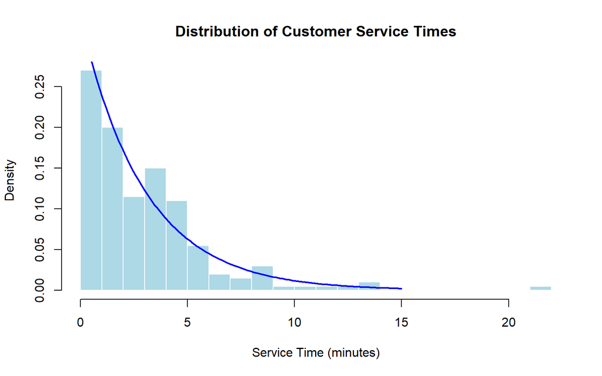

# Monte Carlo Simulation

# What is Monte Carlo Simulation?

Monte Carlo methods use repeated random sampling to:

1. Define the domain of possible inputs
2. Generate inputs randomly from the domain
3. Perform computations using these inputs
4. Aggregate the results

# Applications of Monte Carlo Simulation

- Statistics and probability calculations
- Finance for risk assessment
- Physics and chemistry simulations
- Engineering for reliability analysis
- Machine learning for uncertainty estimation

# Estimating Probabilities: Example 1

**Probability of rolling a sum of 7 with two dice**:

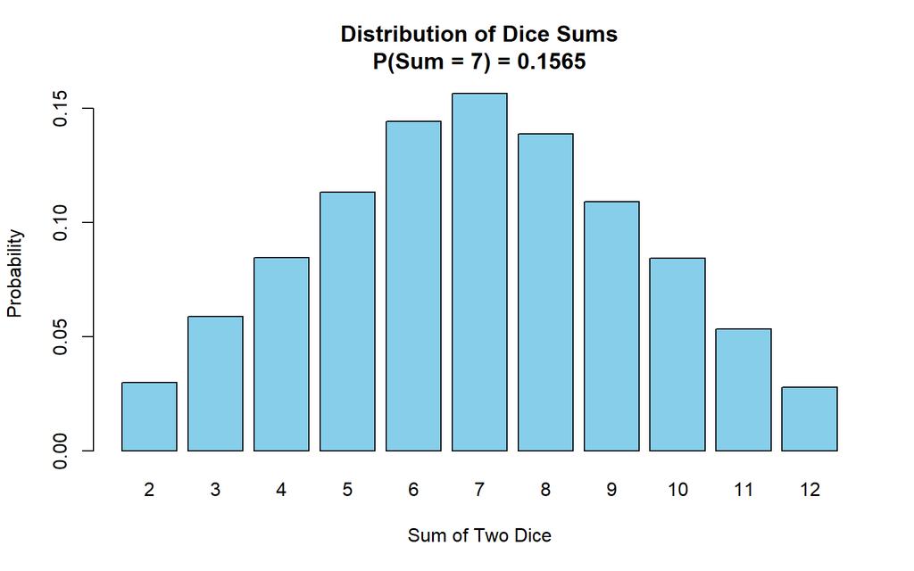

# Monte Carlo for Probability: Code

```r
# Function to simulate rolling two dice
roll_two_dice <- function() {
  sum(sample(1:6, 2, replace = TRUE))
}

# Run many simulations
rolls <- replicate(10000, roll_two_dice())

# Estimate the probability
prob_sum_7 <- mean(rolls == 7)
cat("Estimated probability:", prob_sum_7, "\n")
cat("Theoretical probability:", 6/36, "\n")
```

[output not shown]

# Estimating π Using Monte Carlo

Using random points in a square to estimate π:

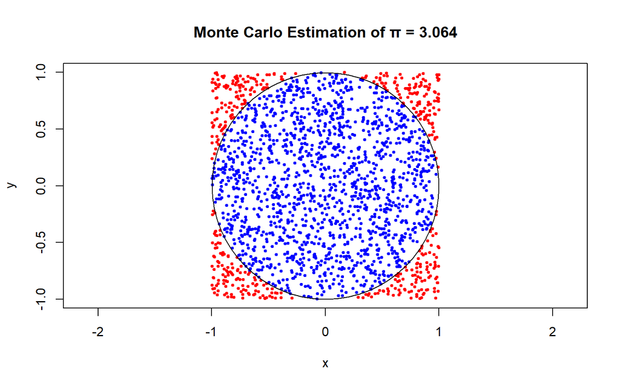

# Monte Carlo Integration

Numerical integration using random numbers:

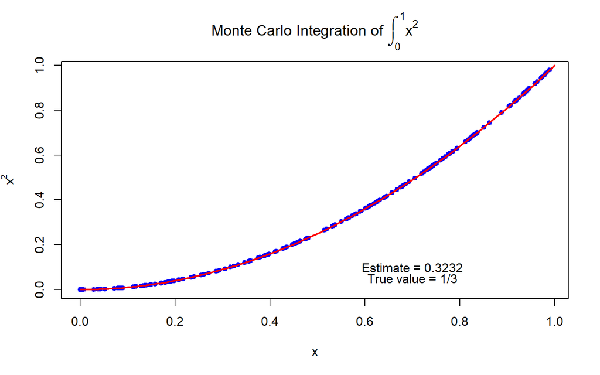

# Estimating Expected Values

Monte Carlo for expected values of complex distributions:

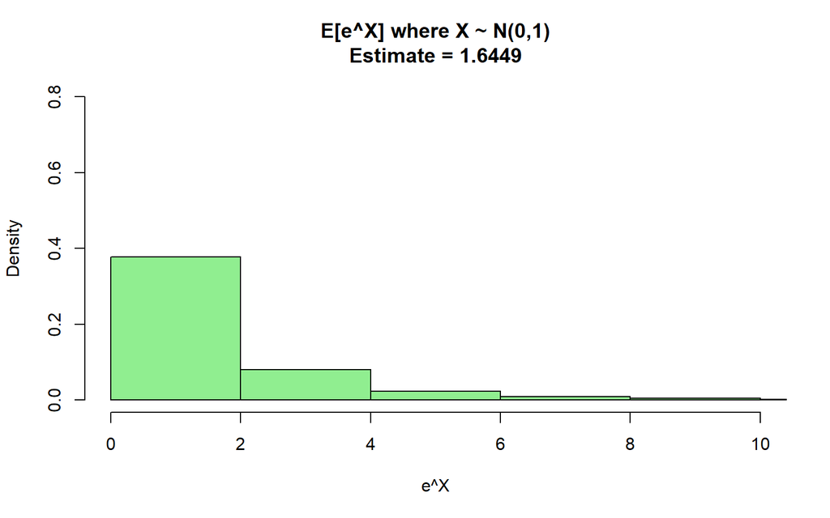

# Portfolio Returns Simulation

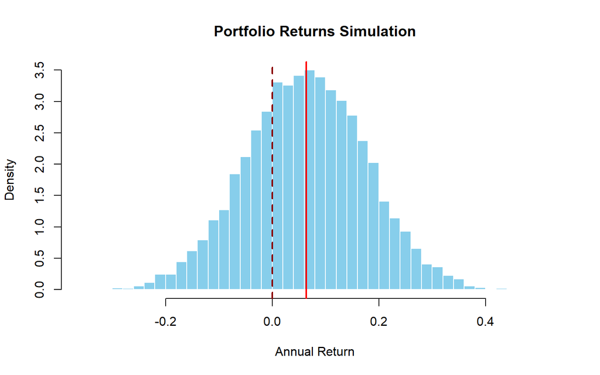

# Portfolio Returns: Key Statistics

For a portfolio with 60% stocks, 35% bonds, and 5% cash:

```
## Expected portfolio return: 6.36 %
```

```
## Portfolio risk (standard deviation): 11.2 %
```

```
## Probability of negative return: 28.61 %
```

# Advanced Topics

# Central Limit Theorem

As sample size increases, the distribution of sample means approaches a normal distribution:

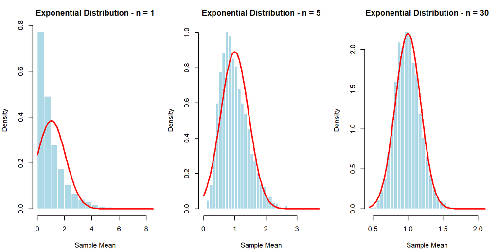

# Effects of Outliers on Regression

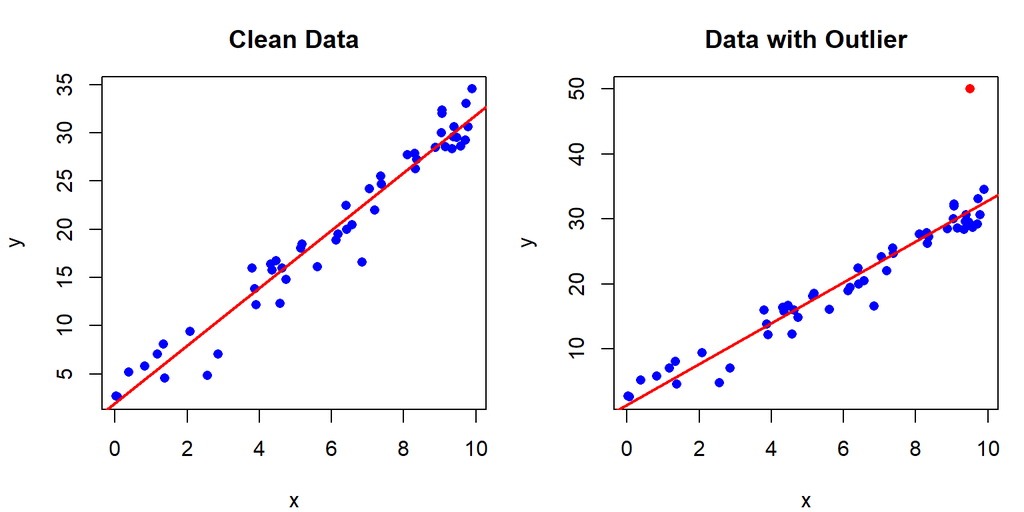

# Regression Coefficients Comparison

```
## Clean data model: y = 1.93 + 2.99 x
```

```
## Outlier data model: y = 1.43 + 3.14 x
```

# Bootstrap Resampling

Estimating sampling distributions by resampling the original data:

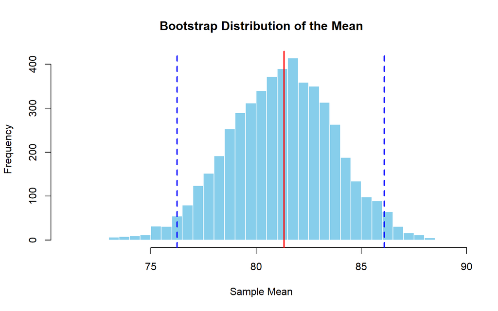

# Bootstrap: Key Results

For our original sample:

```
## Original sample mean: 81.33333
```

```
## 95% bootstrap confidence interval: 76.25 to 86.08333
```

# Practice Exercise: Basic Probability

**Problem**: What’s the probability of at least one 6 in three dice rolls?

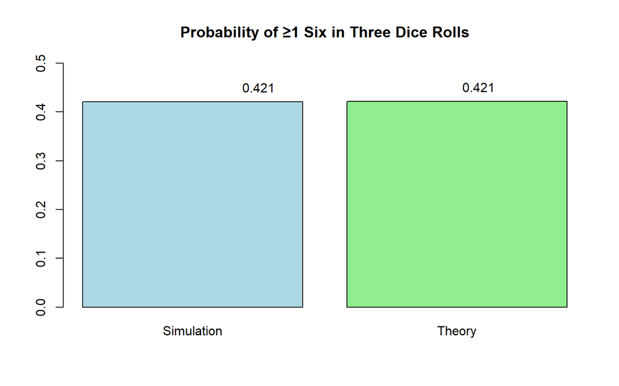

# Practice Exercise: Confidence Intervals

How sample size affects confidence interval width:

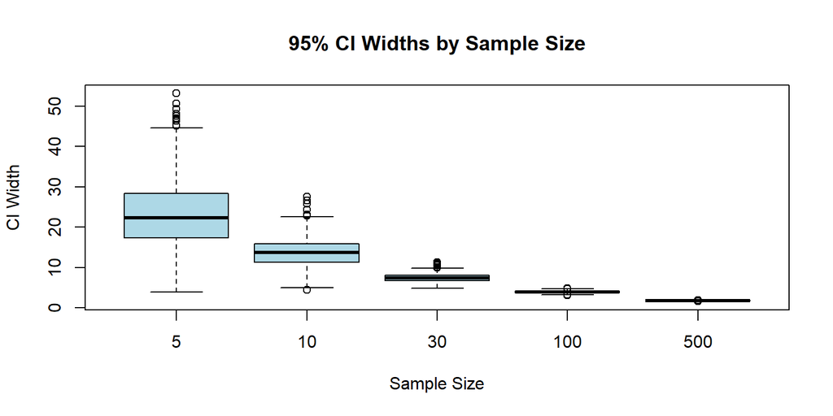

# Conclusion

# Key Takeaways

- **Statistical Programming** combines programming and statistics for data analysis
- **Probability Distributions** model different types of random phenomena
- **Simulation Techniques** allow us to:
  - Generate synthetic data for testing
  - Estimate complex probabilities
  - Calculate integrals and expected values
  - Verify statistical theories
  - Assess statistical method robustness

# Further Reading

1. Ross, S. M. (2013). Simulation. Academic Press.
2. Robert, C. P., & Casella, G. (2010). Monte Carlo Statistical Methods. Springer.
3. Rizzo, M. L. (2019). Statistical Computing with R. CRC Press.
4. Wickham, H., & Grolemund, G. (2017). R for Data Science. O’Reilly Media.

# Thank You!

Questions?

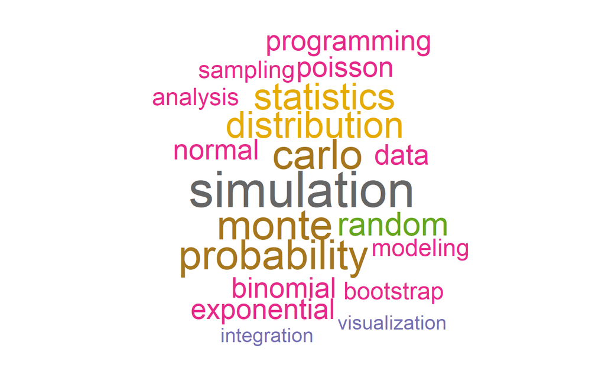